# Deriving valuable insights from marketing dataset

We are going to use public dataset from Kaggle. Data was uploaded by anonimous XYZ e-commerce company with their own online marketplace.

Online marketplace (or online e-commerce marketplace) is a type of e-commerce website where product or service information is provided by multiple third parties. Online marketplaces are the primary type of multichannel ecommerce and can be a way to streamline the production process.

Key objectives of these analysis:

1. Calculate retention rates for:
   - different sales channels
   - different order types

Suggest how we can improve retention rates.

Suggest metrics we need to calculate that can prove/disprove our hyposesis.

1. Identify different customer segments
2. Compare customer segments and analyse their trends

## 0. Preparation stage

### Preparing python environment

```python
#importing nessesary libraries for our analysis
import numpy as np
import pandas as pd
import matplotlib
import matplotlib.pyplot as plt
import seaborn as sns
import datetime as dt

matplotlib.use('TkAgg')
%matplotlib inline
```

### Loading and preparing the data

```python
#load dataset.csv
marketing = pd.read_csv('Dataset.csv', date_parser='Date_Sent')
```

```python
#printing first 5 rows of the dataset
marketing.head()
```

|  | Order_Id | User_Id | Date_Sent | Order_Type | Order_Status | Sales_Channel_Id | Total_GMV | Device | Browser | Marketing_Channel | Country | Marketing_Emails_Sent | Routed_Order | Shipping_Method | Taxed |
| --- | --- | --- | --- | --- | --- | --- | --- | --- | --- | --- | --- | --- | --- | --- | --- |
| 0 | 309558.900 | 5852519 | 6/1/2018 | external | canceled | 4 | 3582 | Desktop | Chrome | Other | United Kingdom | 27 | No | USPS | No |
| 1 | 256562.140 | 5892815 | 6/1/2018 | external | fulfilled | 1 | 1286 | Desktop | Chrome | Google Paid search | United States | 9 | Yes | UPS | No |
| 2 | 75145.758 | 184 | 6/1/2018 | external | fulfilled | 1 | 2487 | Desktop | Chrome | Direct | United States | 13 | Yes | UPS | Yes |
| 3 | 176714.211 | 5816705 | 6/1/2018 | external | fulfilled | 1 | 3024 | Desktop | Safari | Other | Vietnam | 2 | Yes | DHL | Yes |
| 4 | 176714.212 | 5816705 | 6/1/2018 | external | fulfilled | 1 | 4936 | Desktop | Chrome | Google Paid search | United States | 11 | No | DHL | Yes |

```python
#get dataset's information for better understanding of data types of columns
marketing.info()
```

```
<class 'pandas.core.frame.DataFrame'>
RangeIndex: 255662 entries, 0 to 255661
Data columns (total 15 columns):
 #   Column                 Non-Null Count   Dtype
---  ------                 --------------   -----
 0   Order_Id               255662 non-null  float64
 1   User_Id                255662 non-null  int64
 2   Date_Sent              255662 non-null  object
 3   Order_Type             255662 non-null  object
 4   Order_Status           255662 non-null  object
 5   Sales_Channel_Id       255662 non-null  int64
 6   Total_GMV              255662 non-null  int64
 7   Device                 255662 non-null  object
 8   Browser                255662 non-null  object
 9   Marketing_Channel      255662 non-null  object
 10  Country                255662 non-null  object
 11  Marketing_Emails_Sent  255662 non-null  int64
 12  Routed_Order           255662 non-null  object
 13  Shipping_Method        255662 non-null  object
 14  Taxed                  255662 non-null  object
dtypes: float64(1), int64(4), object(10)
memory usage: 29.3+ MB
```

```
Dataset is of a medium size with around 250,000 rows and 15 columns.

Columns don't have any null values and most of the them have right data types (except date_sent which should be converted to datetime)
```

```python
#check how many unique values each column has
marketing.nunique()
```

```
Order_Id                 232599
User_Id                   12721
Date_Sent                   184
Order_Type                    3
Order_Status                  4
Sales_Channel_Id              4
Total_GMV                 10491
Device                        4
Browser                       5
Marketing_Channel            11
Country                       7
Marketing_Emails_Sent        28
Routed_Order                  2
Shipping_Method               4
Taxed                         2
dtype: int64
```

```
As we can see, there are multiple columns with just a few unique values. Later on we can use them in groupby and other aggregation analysis.
```

```python
#print top 10 most frequest values from each column
for col in marketing.columns:
    print('\n-------------')
    print(marketing.groupby([col])[col].count().sort_values(ascending=False).iloc[:10])
    print('-------------')
```

[output not shown]

[output cut: 114 more lines]

[output not shown]

```
That was the last data quality check in order to find 'null' values in a string form. However, no significant numbers of nulls were found.
```

```
Finally, data transformations:
```

```python
#set column names to lowecase for easier code-writing later on
marketing.columns = marketing.columns.str.lower()

#convert date_sent column to datetime format
marketing['date_sent'] = pd.to_datetime(marketing['date_sent'])
```

#### Dataset summary:

- Data is clean and doesn't have any missing values
- Data doesnt seems to have any null values in a string form
- All columns have right data types

# 1. Calculating retention rates

```
Calculation of retention rates for multiple categories is a lengthy process that requires various data manipulations and graph functions. Therefore, to avoid repetetive actions we will define a function plot_retention that will do all the calculations for us.
```

```python
#function that shows figure object
#since we are working in Jupyter Notebook Figure.show() doesnt work.
def show_figure(fig):

    # create a dummy figure and use its manager to display "fig"
    dummy = plt.figure()
    new_manager = dummy.canvas.manager
    new_manager.canvas.figure = fig
    fig.set_canvas(new_manager.canvas)

def plot_retention(dataframe, col, orders=20):

    #instantiating figure & axis objects
    fig = plt.Figure(figsize=(20,8), dpi=150, facecolor='xkcd:white')
    ax1 = fig.add_subplot(1,2,1)
    ax2 = fig.add_subplot(1,2,2)

    #creating empty dataframe to concat all df later on
    total = pd.DataFrame()

    #Part 1: inetrate over subcategories in specified column
    for subcategory in np.unique(dataframe[col]):
        user_dict={}
        user_list=[]

        #Part 2: interate over user ids that belong to specific category
        #and count number of repetitive purchases
        for user in dataframe[dataframe[col]==subcategory]['user_id']:
            if user in user_dict:
                user_dict[user]+=1
            else:
                user_dict[user]=1
            user_list.append(user_dict[user]) #how many repetitive orders each unique customer made

        #Part 3: transform created list to dataframe and normalize values
        df = pd.DataFrame(user_list, columns={'order'}).groupby('order')['order'].count()
        df = pd.DataFrame(dict(orders_number=df.index, frequency=df.values))

        #limiting final dataframe to specific orders number (def=20)
        df = df[df['orders_number']<=orders]

        #calculating retention rate percentage
        df['percent'] = df['frequency'].divide(df['frequency'].max()/100)

        #creating total dataframe that will be used when plotting heatmap (seaborn)
        pre_total = pd.DataFrame()
        pre_total['{}: {}'.format(col, subcategory)] = df['percent']
        total = pd.concat([pre_total, total], axis=1, ignore_index=False)

        #Part 4: creating linear plots for retention

        #creating ax1 plot
        ax1.plot(df['orders_number'], df['frequency'])

        #editing style of ax1 plot
        ax1.set_title('Retention plot for {}s (Number of orders) \n'.format(col, subcategory))
        ax1.set_xlabel('\nNumber of orders per customer')
        ax1.set_ylabel('Number of orders')
        ax1.set_xticks(np.arange(1, orders+1))
        ax1.set_xticklabels(range(1,orders+1))
        ax1.legend(np.unique(dataframe[col]), title='{}s:'.format(col))

        #creating ax2 plot
        ax2.plot(df['orders_number'], df['percent'])

        #editing style of ax2 plot
        ax2.set_title('Retention plot for {}s (Percent from orders) \n'.format(col, subcategory))
        ax2.set_xlabel('\nNumber of orders per customer')
        ax2.set_ylabel('Percent from first order')
        ax2.set_xticks(np.arange(1, orders+1))
        ax2.set_xticklabels(range(1,orders+1))
        ax2.legend(np.unique(dataframe[col]), title='{}s:'.format(col))

    #showing lineplot of retention rates
    show_figure(fig)

    #Part 5: creating heatmap plot using seaborn library

    #creating figure and axes objects
    fig2, ax = plt.subplots(figsize=(10,8), dpi=150, facecolor='xkcd:white')

    #creating seaborn plot
    sns.heatmap(total.T, square=True, annot=True, cmap = sns.cm.rocket_r, cbar=False, fmt='.1f')

    #editing style of heatmap plot
    ax.set_xticks(np.arange(0.5, orders+0.5))
    ax.set_xticklabels(range(1,orders+1))
    plt.title('Heatmap plot for {} retention rate (%)\n'.format(col))
    plt.xlabel('\nRepeated orders')
```

```
Above we succesfully defined plot_retention function that plots retention rates of our customers.

Lets finally start plotting and analysing!
```

### Retention rates for 4 different sales channels:

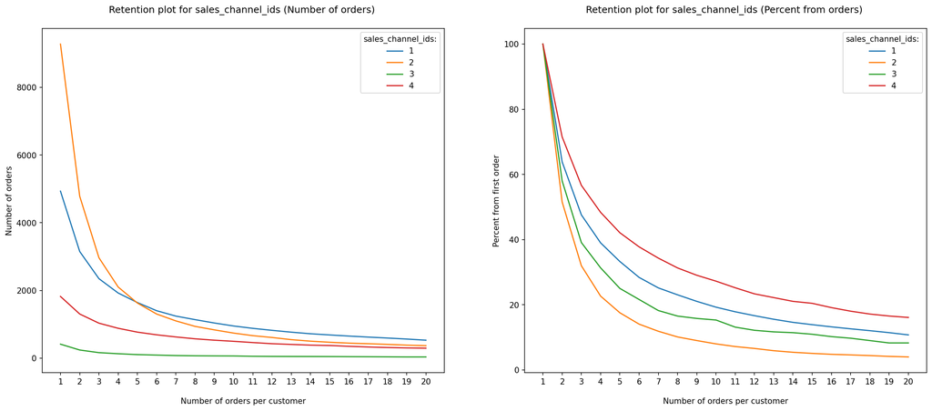

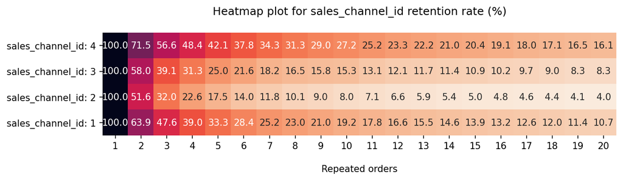

```python
#remove cancelled orders before plotting retentions
fulfilled = marketing[marketing['order_status']=='fulfilled']

#plot retentions for different sales_channel_ids by limiting number of repeated orders to 20
plot_retention(fulfilled, 'sales_channel_id', orders=20)
```

```
Check which sales channels use which order type:
```

```python
fulfilled.groupby(['sales_channel_id', 'order_type'])['user_id'].count().unstack(level=1)
```

| order_type sales_channel_id | external | manual | sample |
| --- | --- | --- | --- |
| 1 | 120899.0 | NaN | NaN |
| 2 | NaN | 58942.0 | 18714.0 |
| 3 | 3467.0 | NaN | NaN |
| 4 | 49157.0 | NaN | NaN |

```
Check the volume for each sales channel:
```

```python
total = fulfilled.groupby('sales_channel_id')['user_id'].count()
round(total.divide(sum(total)),3)
```

```
sales_channel_id
1    0.481
2    0.309
3    0.014
4    0.196
Name: user_id, dtype: float64
```

### Analysis of retention rates for sales channels

According to the top right graph and volume table we can easily see that:

1. Customers are not satisfied with the quality of the product or delivery/waiting time

   In this case, we would need to conduct a small survey specifically for channel 2 buyers after the first order was delivered. Key objective is to find any problems they could encounter, whether it was delivery or quality. As a result try to work out solutions for these problems. Finally, recalculate retention rate after the changes to see if it showed any improvements.
2. Channel brings mostly one-time buyers

   One-time buyers could be small businesses ordering merchandise for their employees. Those customers may not need our products every month but if we keep sending them marketing emails every couple of months, they may return again. Dataset is relatively small and includes only a 6 month time period, which is probably not enough to measure the size of this customer segment.
3. Customers quickly lose interest

   Here we can try a few strategies: increase the number of marketing emails sent after the first purchase or conduct A/B testing by changing product recommendation algorithms. In the first case, we would need to recalculate retention rate to measure the effect. In the second case, we would need to compare distributions of purchases for both cases using T-test (to see significance of the effect and exclude randomness), then calculate retention rates to compare both cases to see which is better.
4. As seen from the table after retention plots, channel uses only manual and sample order types which show the lowest retention rates (check order types retention graphs)

   See recomendations in analysis of order types section below.

### Retention rates for 3 different order types:

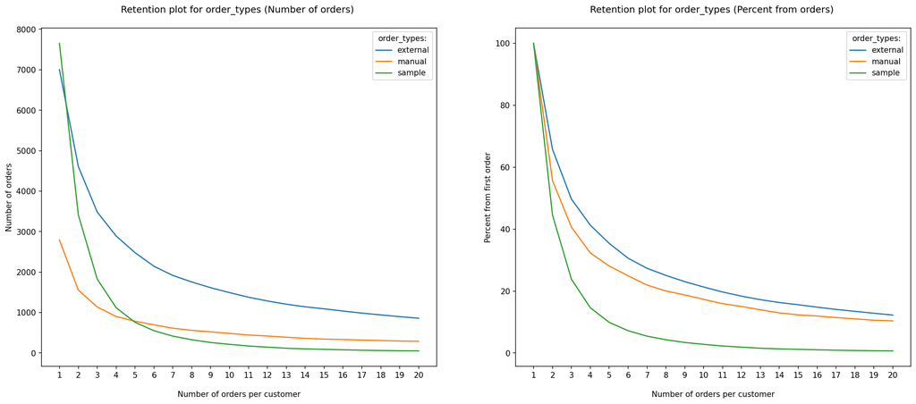

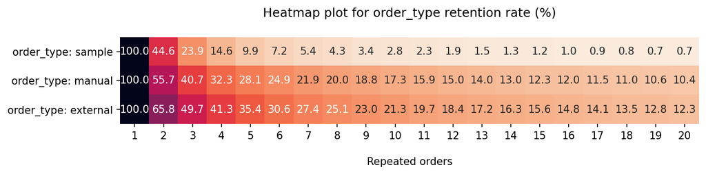

```python
#plotting retention for order_types
plot_retention(fulfilled, 'order_type', orders=20)
```

```
Check the volume for each order type:
```

```python
total = fulfilled.groupby('order_type')['user_id'].count()
round(total.divide(sum(total)),2)
```

```
order_type
external    0.69
manual      0.23
sample      0.07
Name: user_id, dtype: float64
```

#### Analysis of retention rates for order types

According to the top right graph and volume table we can easily see that:

- External order type has the largest orders volume and the highest retention rate
- Manual order type has second highest volume and close to external retention rate
- Sample order type has the highest amount of first time purchases but the lowest total volume and retention rate.

Brief description of 3 order types:

- Sample order type - orders that are made on our platform. Allows customers to place one-time order before fully starting using the platform and ordering in larger quantities
- Manual order type - orders that are made on our platform. Allows customers to manually confirm their orders on our platform
- External order type - orders that come from other platforms that use our marketplace.

We know that manual and sample order types are used only at sales channel 2 and nowhere else (see the first table after retention plots for sales channels). It comes with no surprise that sample order type shows the lowest retention rate since its idea is about one-time purchases, such that customers can try our product and see the quality before ordering in larger amounts. However, manual order type could have a better retention rate and before suggesting any improvements read the following:

```
According to research firm Baymond Institute the average cart abandonment rate is 69.23%. This abandonment rate indicates the ratio of your website visitors who started to make a booking, but never completed their purchase. The same study also found that an optimized checkout, one that focuses on usability and design, can increase overall website conversion rates by 35.26%.
```

Therefore, with manual order type we can have the following problems:

- Customers place orders in baskets and forget about them

  First of all, check how many orders end up in the baskets but never purchased. If there are large numbers of those orders the solution is simple - remind them about placed orders. We should send them an email after an hour of inactivity. After a month since we started, check email response rates and recalculate retention rate to see the effect.
- Customers find purchase experience unintuitive and therefore lose interest in proceeding with purchase

  Here we should check which pages of our website show the highest leave rate after the customer placed an order. After finding those, we can conduct A/B testing by changing page's template. Finally, compare distributions of purchases using T-test to see significance of the effect (and exclude randomness) and then calculate retention rates to compare both cases to see which is better.

# 2. Identifying different customer segments

In order to better understand our customers and what they prefer we need to perform segmentation analysis. We are going to use RFM segmentation technique which is commonly used in database marketing and direct marketing and has received particular attention in retail and professional services industries.

RFM stands for the three dimensions:

- Recency – How recently did the customer purchase?
- Frequency – How often do they purchase?
- Monetary Value – How much do they spend?

## Conducting RFM segmentation:

```python
cols = ['user_id', 'date_sent', 'order_id', 'total_gmv']

#convert date_sent column to datetime
marketing['date_sent'] = pd.to_datetime(marketing['date_sent'])

#create date as if we are working with the recent dataset
last_date = marketing['date_sent'].max()+dt.timedelta(days=1)

# Aggregate data on a customer level
rfm = marketing[cols].groupby(['user_id']).agg({'date_sent': lambda x: (last_date - x.max()).days,
                                                'order_id': 'count',
                                                'total_gmv': 'sum'})

# Rename columns for easier interpretation
rfm.rename(columns = {'date_sent': 'Recency',
                      'order_id': 'Frequency',
                      'total_gmv': 'MonetaryValue'}, inplace=True)

#generating quartiles for recency col
r_labels = range(4, 0, -1)
r_quartiles = pd.qcut(rfm['Recency'], 4, labels = r_labels)
rfm['R'] = r_quartiles.values

#generating quartiles for frequency col
f_labels = range(1,5)
f_quartiles = pd.qcut(rfm['Frequency'].rank(method='first'), 4, labels = f_labels)
rfm['F'] = f_quartiles.values

#generating quartiles for monetaryvalue col
m_labels = range(1,5)
m_quartiles = pd.qcut(rfm['MonetaryValue'], 4, labels = m_labels)
rfm['M'] = m_quartiles.values

#defining key RFM metrics
rfm['rfm_segment'] = rfm['R'].astype(str) + rfm['F'].astype(str) + rfm['M'].astype(str)
rfm['rfm_score'] = rfm[['R', 'F', 'M']].sum(axis=1)
```

```
Above we have assigned each unique customer to specific segment based on his/her RFM score. Now we will group customers by those segments and compute summary statistics:
```

```python
score_segmentation = rfm.groupby('rfm_score').agg({'Recency':'mean',
                                                   'Frequency':'mean',
                                                   'MonetaryValue':['mean', 'count']}).round(2)

score_segmentation
```

| rfm_score | Recency mean | Frequency mean | MonetaryValue mean | MonetaryValue count |
| --- | --- | --- | --- | --- |
| 3 | 144.64 | 1.00 | 1801.75 | 1122 |
| 4 | 114.61 | 1.09 | 2981.73 | 1168 |
| 5 | 94.93 | 1.37 | 4328.84 | 1322 |
| 6 | 68.23 | 1.62 | 5102.68 | 1471 |
| 7 | 61.54 | 2.21 | 7666.93 | 1498 |
| 8 | 51.64 | 3.16 | 11319.40 | 1361 |
| 9 | 41.53 | 6.86 | 21115.46 | 1192 |
| 10 | 30.40 | 10.04 | 30708.67 | 1071 |
| 11 | 17.68 | 22.21 | 61263.98 | 935 |
| 12 | 4.03 | 127.61 | 278035.40 | 1581 |

```
As we can see, created segments are very clear and logical. The higher the rfm_score of the group of customers the lower recency (which is good), higher frequency and higher monetary value. Moreover, number of customers in each segment seems more or less uniformly distributed which is also good.
```

We will reduce number of segments for easier further analysis. Moreover, we will name them in an intuitive way:

- Best performing customers - Gold segment
- Well performing customers - Silver segment
- Worst performing customers - Bronze segment

```python
#defining rfm_level function which will rename our segments
def rfm_level(df):
    if df['rfm_score'] >= 10:
        return 'Gold'
    elif ((df['rfm_score'] >= 6) and (df['rfm_score'] < 10)):
        return 'Silver'
    else:
        return 'Bronze'

# Create a new column RFM_Level which is a rename of rfm_score column
rfm['rfm_level'] = rfm.apply(rfm_level, axis=1)
```

```
We have reduced number of segments to 3 and named them in and intuitive way.

Its time for segment analysis!
```

# 3. Comparing customer segments and analysing their trends

Firstly, lets calculate summary statistics for new segments and compare them:

```python
#calculating summary statistics
segments = rfm.groupby('rfm_level').agg({ 'Recency':'mean',
                                          'Frequency':'mean',
                                          'MonetaryValue':['mean', 'count']})\
                                          .round(1).sort_values(('MonetaryValue','mean'), ascending=False)

segments
```

| rfm_level | Recency mean | Frequency mean | MonetaryValue mean | MonetaryValue count |
| --- | --- | --- | --- | --- |
| Gold | 15.5 | 65.0 | 147684.6 | 3587 |
| Silver | 56.6 | 3.3 | 10787.1 | 5522 |
| Bronze | 116.7 | 1.2 | 3108.2 | 3612 |

```
 As we can see, Gold segment has 14 times larger average monetary value than Silver, much higher frequency of orders and the lowest recency. Bronze segment's performance is way below Gold and Silver.

Next step, map our segments back to the original dataset for further analysis:
```

```python
combined = pd.merge(left=marketing, right=rfm.iloc[:,-1], left_on='user_id', right_on=rfm.index, how='left')
```

```
Previously we have separated our customers into three segments but now lets check percent from total orders that each segment represents:
```

```python
segments_orders = combined['rfm_level'].value_counts()
segments_orders.divide(segments_orders.sum())
```

```
Gold      0.912427
Silver    0.071086
Bronze    0.016487
Name: rfm_level, dtype: float64
```

```
91% of all orders belong to Gold segment! 7% to Silver and only 1.6% to Bronze.

Since Gold customers have the largest volume and average monetary values we can expect them to have the best retention rate as well. Lets plot retetion rates using previously defined function:
```

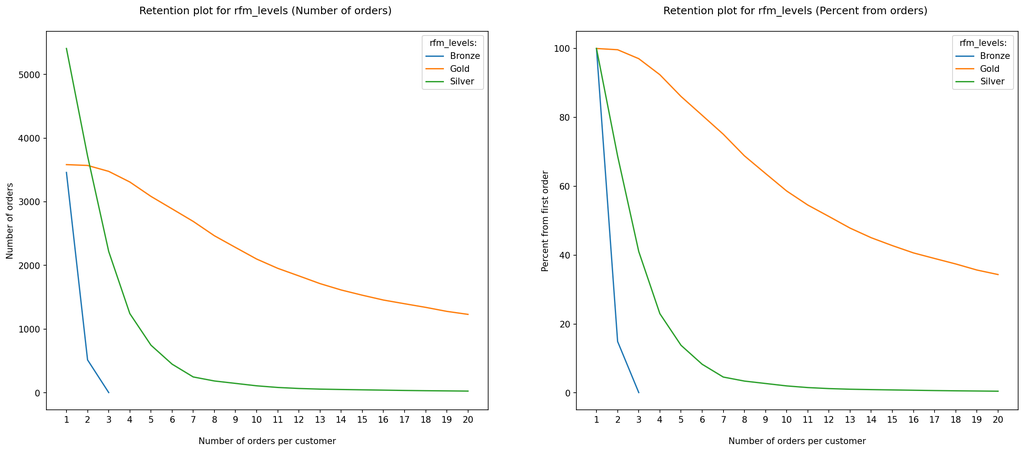

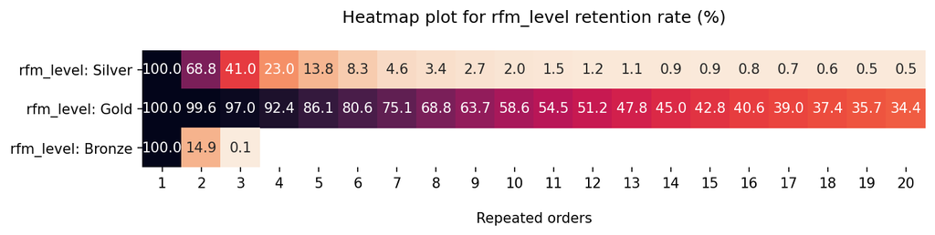

```python
#remove cancelled orders before plotting retentions
fulfilled_combined = combined[combined['order_status']=='fulfilled']

plot_retention(fulfilled_combined, 'rfm_level')
```

```
Expectedly, customers in Gold segment have the highest retention rate, much better than in other 2. What is also interesting is that their average order value (Total_GMV) is the lowest, see the graph below:
```

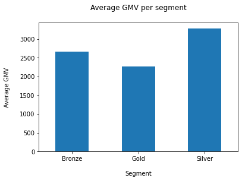

```python
#fig, ax = plt.subplots(figsize=(5,4), dpi=150)
ax = round(combined.groupby(['rfm_level'])['total_gmv'].mean(),0).plot(kind='bar')
plt.title('Average GMV per segment\n')
plt.xlabel('\nSegment')
plt.ylabel('Average GMV\n')
ax.set_xticklabels(['Bronze', 'Gold', 'Silver'],rotation=0);
```

```
Remember that Gold customers have 14 times higher average monetary value than Silver ones. Now, even though their average GMV per order is the lowest, because of the high retention rate they bring much more to the business than other segments.

Last thing to analyse is where each segment comes from and which order type uses.
```

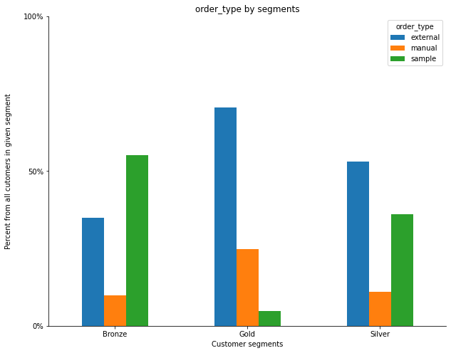

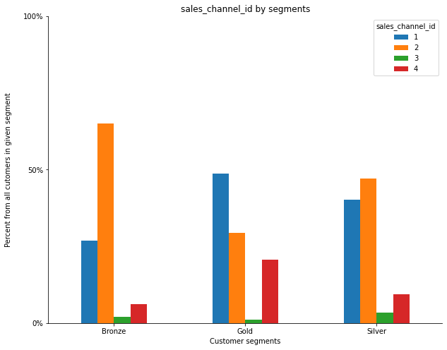

```python
str_cols=['order_type', 'sales_channel_id']

for col in str_cols:
    df = combined.groupby([col,'rfm_level'])[col].count().unstack(level=1)
    df = df.divide(df.sum()).T
    ax = df.plot(kind='bar', figsize=(10,8))

    plt.title('{} by segments'.format(col))
    plt.ylabel('Percent from all cutomers in given segment\n')
    plt.yticks(ticks=[0,0.5,1], labels=['0%', '50%', '100%'], rotation=0)
    plt.ylim(0,1)
    plt.xlabel('Customer segments')
    plt.xticks(rotation=0)
    sns.despine()

    plt.show()
```

[output not shown]

### Segmentation Summary:

```
If we want to acquire more Gold and Silver customers in the future we should focus on advertising sales channel 1, then 2 and 4. Similar for order types, we should focus on promoting external type first, than manual and sample.
```